# Homework 3

Author

Sydney Ball

## Homework 3

The primary goal of homework 3 is to give you hands-on practice with the assignment operator and a number of dplyr verbs we went over in Lecture 3.

For you convenience, a copy of the Lecture 3 slides is located here: https://jmtfeliciano.github.io/DATA312Spring2025/Data312Spring2025_Lecture3#1

You may use the filled in Exercise 3 HTML page as a reference guide:

https://jmtfeliciano.github.io/DATA312Spring2025/Exercise3FilledIn.html

## What you need to do

You will be assigned tasks throughout this Quarto Document where you will need to fill in the relevant R code based on what was taught in Lecture 3 slides and Data312Exercise3.qmd … Topics from older lectures may also be revisited for practice.

## Task 1 (1 pt)

Within the R code chunk below, write an R script to (1) load the **tidyverse** package, (2) load the built-in dataset called **midwest** into your R environment, and (3) print a sample of the midwest data by using head() or glimpse(). Afterwards, spend a minute or two examining the printed data to understand the general contents of the **midwest** data.

```r
# Include your code below:
library(tidyverse)
data("midwest")

print(head(midwest))
```

```
# A tibble: 6 × 28
    PID county   state  area poptotal popdensity popwhite popblack popamerindian
  <int> <chr>    <chr> <dbl>    <int>      <dbl>    <int>    <int>         <int>
1   561 ADAMS    IL    0.052    66090      1271.    63917     1702            98
2   562 ALEXAND… IL    0.014    10626       759      7054     3496            19
3   563 BOND     IL    0.022    14991       681.    14477      429            35
4   564 BOONE    IL    0.017    30806      1812.    29344      127            46
5   565 BROWN    IL    0.018     5836       324.     5264      547            14
6   566 BUREAU   IL    0.05     35688       714.    35157       50            65
# ℹ 19 more variables: popasian <int>, popother <int>, percwhite <dbl>,
#   percblack <dbl>, percamerindan <dbl>, percasian <dbl>, percother <dbl>,
#   popadults <int>, perchsd <dbl>, percollege <dbl>, percprof <dbl>,
#   poppovertyknown <int>, percpovertyknown <dbl>, percbelowpoverty <dbl>,
#   percchildbelowpovert <dbl>, percadultpoverty <dbl>,
#   percelderlypoverty <dbl>, inmetro <int>, category <chr>
```

## Task 2

Within your R Console, run one of the following scripts: **help(midwest)** or **?midwest**

After the documentation opens up in your Help pane, answer the following questions below:

### 2.a. What is the data about? (0.5 pt)

Your response (1-2 sentences):

> The Midwest dataset concerns demographic information of Midwest counties from 2000 US census.

### 2.b. Which specific variable represents (1) county names, (2) percentage of children below poverty line and (3) percentage of white Americans? (0.5 pt)

Your response (1-3 sentences):

> The variable which represents county namesL county; percentage of children below poverty line: percchildbelowpovert, and percentage of white American: percwhite.

## Task 3 (0.5 pt)

Using the R code chunk below, print a data subset of **midwest** where **inmetro** is equals to **1**

**Hint:** See Practice 1 from https://jmtfeliciano.github.io/DATA312Spring2025/Exercise3FilledIn.html to see an example where I ask you to print a data subset

```r
# Include your code below:
task3 <- midwest |>
  filter(inmetro == 1)

task3
```

```
# A tibble: 150 × 28
     PID county  state  area poptotal popdensity popwhite popblack popamerindian
   <int> <chr>   <chr> <dbl>    <int>      <dbl>    <int>    <int>         <int>
 1   564 BOONE   IL    0.017    30806      1812.    29344      127            46
 2   570 CHAMPA… IL    0.058   173025      2983.   146506    16559           331
 3   574 CLINTON IL    0.029    33944      1170.    32688     1021            48
 4   576 COOK    IL    0.058  5105067     88018.  3204947  1317147         10289
 5   579 DE KALB IL    0.038    77932      2051.    72968     2069           123
 6   582 DU PAGE IL    0.02    781666     39083.   714905    15462           962
 7   592 GRUNDY  IL    0.026    32337      1244.    31864       21            45
 8   597 HENRY   IL    0.051    51159      1003.    49969      657            63
 9   602 JERSEY  IL    0.023    20539       893     20346       96            43
10   605 KANE    IL    0.029   317471     10947.   269675    19006           620
# ℹ 140 more rows
# ℹ 19 more variables: popasian <int>, popother <int>, percwhite <dbl>,
#   percblack <dbl>, percamerindan <dbl>, percasian <dbl>, percother <dbl>,
#   popadults <int>, perchsd <dbl>, percollege <dbl>, percprof <dbl>,
#   poppovertyknown <int>, percpovertyknown <dbl>, percbelowpoverty <dbl>,
#   percchildbelowpovert <dbl>, percadultpoverty <dbl>,
#   percelderlypoverty <dbl>, inmetro <int>, category <chr>
```

## Task 4 (0.5 pt)

Using the R code chunk below, print a data subset of **midwest** where **state** is equals to **IL**

```r
# Include your code below:
task4 <- midwest |>
  filter(state == "IL")

task4
```

```
# A tibble: 102 × 28
     PID county  state  area poptotal popdensity popwhite popblack popamerindian
   <int> <chr>   <chr> <dbl>    <int>      <dbl>    <int>    <int>         <int>
 1   561 ADAMS   IL    0.052    66090      1271.    63917     1702            98
 2   562 ALEXAN… IL    0.014    10626       759      7054     3496            19
 3   563 BOND    IL    0.022    14991       681.    14477      429            35
 4   564 BOONE   IL    0.017    30806      1812.    29344      127            46
 5   565 BROWN   IL    0.018     5836       324.     5264      547            14
 6   566 BUREAU  IL    0.05     35688       714.    35157       50            65
 7   567 CALHOUN IL    0.017     5322       313.     5298        1             8
 8   568 CARROLL IL    0.027    16805       622.    16519      111            30
 9   569 CASS    IL    0.024    13437       560.    13384       16             8
10   570 CHAMPA… IL    0.058   173025      2983.   146506    16559           331
# ℹ 92 more rows
# ℹ 19 more variables: popasian <int>, popother <int>, percwhite <dbl>,
#   percblack <dbl>, percamerindan <dbl>, percasian <dbl>, percother <dbl>,
#   popadults <int>, perchsd <dbl>, percollege <dbl>, percprof <dbl>,
#   poppovertyknown <int>, percpovertyknown <dbl>, percbelowpoverty <dbl>,
#   percchildbelowpovert <dbl>, percadultpoverty <dbl>,
#   percelderlypoverty <dbl>, inmetro <int>, category <chr>
```

## Task 5 (0.5 pt)

Using the R code chunk below, print a data subset of **midwest** where **state** is equals to **IL** and **inmetro** is equals to **1** (Hint: see *filter() verb - multiple filtering variables section* of Exercise 3)

```r
# Include your code below:
task5 <- midwest |>
  filter(state == "IL") |>
  filter(inmetro == 1)

task5
```

```
# A tibble: 28 × 28
     PID county  state  area poptotal popdensity popwhite popblack popamerindian
   <int> <chr>   <chr> <dbl>    <int>      <dbl>    <int>    <int>         <int>
 1   564 BOONE   IL    0.017    30806      1812.    29344      127            46
 2   570 CHAMPA… IL    0.058   173025      2983.   146506    16559           331
 3   574 CLINTON IL    0.029    33944      1170.    32688     1021            48
 4   576 COOK    IL    0.058  5105067     88018.  3204947  1317147         10289
 5   579 DE KALB IL    0.038    77932      2051.    72968     2069           123
 6   582 DU PAGE IL    0.02    781666     39083.   714905    15462           962
 7   592 GRUNDY  IL    0.026    32337      1244.    31864       21            45
 8   597 HENRY   IL    0.051    51159      1003.    49969      657            63
 9   602 JERSEY  IL    0.023    20539       893     20346       96            43
10   605 KANE    IL    0.029   317471     10947.   269675    19006           620
# ℹ 18 more rows
# ℹ 19 more variables: popasian <int>, popother <int>, percwhite <dbl>,
#   percblack <dbl>, percamerindan <dbl>, percasian <dbl>, percother <dbl>,
#   popadults <int>, perchsd <dbl>, percollege <dbl>, percprof <dbl>,
#   poppovertyknown <int>, percpovertyknown <dbl>, percbelowpoverty <dbl>,
#   percchildbelowpovert <dbl>, percadultpoverty <dbl>,
#   percelderlypoverty <dbl>, inmetro <int>, category <chr>
```

## Task 6 (0.5 pt)

Using the R code chunk below, print a data subset of **midwest** where **state** is equals to either **IL** or **IN**. You must use the in-operator (%in%) taught in lecture.

```r
# Include your code below:
task6 <- midwest |>
  filter(state %in% c("IL", "IN") )

task6
```

```
# A tibble: 194 × 28
     PID county  state  area poptotal popdensity popwhite popblack popamerindian
   <int> <chr>   <chr> <dbl>    <int>      <dbl>    <int>    <int>         <int>
 1   561 ADAMS   IL    0.052    66090      1271.    63917     1702            98
 2   562 ALEXAN… IL    0.014    10626       759      7054     3496            19
 3   563 BOND    IL    0.022    14991       681.    14477      429            35
 4   564 BOONE   IL    0.017    30806      1812.    29344      127            46
 5   565 BROWN   IL    0.018     5836       324.     5264      547            14
 6   566 BUREAU  IL    0.05     35688       714.    35157       50            65
 7   567 CALHOUN IL    0.017     5322       313.     5298        1             8
 8   568 CARROLL IL    0.027    16805       622.    16519      111            30
 9   569 CASS    IL    0.024    13437       560.    13384       16             8
10   570 CHAMPA… IL    0.058   173025      2983.   146506    16559           331
# ℹ 184 more rows
# ℹ 19 more variables: popasian <int>, popother <int>, percwhite <dbl>,
#   percblack <dbl>, percamerindan <dbl>, percasian <dbl>, percother <dbl>,
#   popadults <int>, perchsd <dbl>, percollege <dbl>, percprof <dbl>,
#   poppovertyknown <int>, percpovertyknown <dbl>, percbelowpoverty <dbl>,
#   percchildbelowpovert <dbl>, percadultpoverty <dbl>,
#   percelderlypoverty <dbl>, inmetro <int>, category <chr>
```

## Task 7 (0.5 pt)

Using the R code chunk below, print a data subset of **midwest** where the *percentage of white Americans* (see results of documentation search in Task 2b) is less than 50

```r
# Include your code below:
task7 <- midwest |>
  filter(percwhite < 50)

task7
```

```
# A tibble: 1 × 28
    PID county   state  area poptotal popdensity popwhite popblack popamerindian
  <int> <chr>    <chr> <dbl>    <int>      <dbl>    <int>    <int>         <int>
1  3020 MENOMIN… WI    0.021     3890       185.      416        0          3469
# ℹ 19 more variables: popasian <int>, popother <int>, percwhite <dbl>,
#   percblack <dbl>, percamerindan <dbl>, percasian <dbl>, percother <dbl>,
#   popadults <int>, perchsd <dbl>, percollege <dbl>, percprof <dbl>,
#   poppovertyknown <int>, percpovertyknown <dbl>, percbelowpoverty <dbl>,
#   percchildbelowpovert <dbl>, percadultpoverty <dbl>,
#   percelderlypoverty <dbl>, inmetro <int>, category <chr>
```

## Task 8 (0.5 pt)

Using the R code chunk below, print a data subset of **midwest** after filtering for data where the *county name* (see results of documentation search in Task 2b) is equal to **ADAMS**

```r
# Include your code below:
task8 <- midwest |>
  filter(county == "ADAMS")

task8
```

```
# A tibble: 4 × 28
    PID county state  area poptotal popdensity popwhite popblack popamerindian
  <int> <chr>  <chr> <dbl>    <int>      <dbl>    <int>    <int>         <int>
1   561 ADAMS  IL    0.052    66090      1271.    63917     1702            98
2   663 ADAMS  IN    0.021    31095      1481.    30530       36            42
3  2009 ADAMS  OH    0.035    25371       725.    25212       47            67
4  2981 ADAMS  WI    0.041    15682       382.    15001      375           125
# ℹ 19 more variables: popasian <int>, popother <int>, percwhite <dbl>,
#   percblack <dbl>, percamerindan <dbl>, percasian <dbl>, percother <dbl>,
#   popadults <int>, perchsd <dbl>, percollege <dbl>, percprof <dbl>,
#   poppovertyknown <int>, percpovertyknown <dbl>, percbelowpoverty <dbl>,
#   percchildbelowpovert <dbl>, percadultpoverty <dbl>,
#   percelderlypoverty <dbl>, inmetro <int>, category <chr>
```

## Task 9 (1 pt)

Within the R code chunk below, save a data subset of **midwest** after filtering for data where the *percentage of children below poverty line* (see Task 2b) is over 25 into your R environment as **high_children_poverty**

Afterwards, print a sample of **high_children_poverty** using **head()** or **glimpse()**

```r
# Include your code below:
high_children_poverty <- midwest |>
  filter(percchildbelowpovert > 25 )

high_children_poverty
```

```
# A tibble: 45 × 28
     PID county  state  area poptotal popdensity popwhite popblack popamerindian
   <int> <chr>   <chr> <dbl>    <int>      <dbl>    <int>    <int>         <int>
 1   562 ALEXAN… IL    0.014    10626       759      7054     3496            19
 2   588 FRANKL… IL    0.025    40319      1613.    40068       36           106
 3   590 GALLAT… IL    0.019     6909       364.     6842       42            10
 4   595 HARDIN  IL    0.009     5189       577.     5062       85            16
 5   599 JACKSON IL    0.036    61067      1696.    51991     6342           109
 6   611 LAWREN… IL    0.022    15972       726     15759      151            31
 7   636 POPE    IL    0.022     4373       199.     4072      266            15
 8   637 PULASKI IL    0.011     7523       684.     5032     2466             8
 9   642 ST CLA… IL    0.04    262852      6571.   187866    71275           585
10   643 SALINE  IL    0.022    26551      1207.    25452      931            66
# ℹ 35 more rows
# ℹ 19 more variables: popasian <int>, popother <int>, percwhite <dbl>,
#   percblack <dbl>, percamerindan <dbl>, percasian <dbl>, percother <dbl>,
#   popadults <int>, perchsd <dbl>, percollege <dbl>, percprof <dbl>,
#   poppovertyknown <int>, percpovertyknown <dbl>, percbelowpoverty <dbl>,
#   percchildbelowpovert <dbl>, percadultpoverty <dbl>,
#   percelderlypoverty <dbl>, inmetro <int>, category <chr>
```

## Task 10 (0.5 pt)

```r
# Include your code below:
task10 <- midwest |>
  arrange(poptotal)

task10
```

```
# A tibble: 437 × 28
     PID county  state  area poptotal popdensity popwhite popblack popamerindian
   <int> <chr>   <chr> <dbl>    <int>      <dbl>    <int>    <int>         <int>
 1  1238 KEWEEN… MI    0.02      1701       85.0     1688        1             4
 2  3020 MENOMI… WI    0.021     3890      185.       416        0          3469
 3   636 POPE    IL    0.022     4373      199.      4072      266            15
 4  2999 FLOREN… WI    0.03      4590      153       4562        4            14
 5   595 HARDIN  IL    0.009     5189      577.      5062       85            16
 6   720 OHIO    IN    0.005     5315     1063       5255       41             8
 7   567 CALHOUN IL    0.017     5322      313.      5298        1             8
 8   646 SCOTT   IL    0.015     5644      376.      5634        1             6
 9   638 PUTNAM  IL    0.01      5730      573       5616        9             7
10  1244 LUCE    MI    0.055     5763      105.      5418        2           331
# ℹ 427 more rows
# ℹ 19 more variables: popasian <int>, popother <int>, percwhite <dbl>,
#   percblack <dbl>, percamerindan <dbl>, percasian <dbl>, percother <dbl>,
#   popadults <int>, perchsd <dbl>, percollege <dbl>, percprof <dbl>,
#   poppovertyknown <int>, percpovertyknown <dbl>, percbelowpoverty <dbl>,
#   percchildbelowpovert <dbl>, percadultpoverty <dbl>,
#   percelderlypoverty <dbl>, inmetro <int>, category <chr>
```

## Task 11 (0.5 pt)

Within the R code chunk below, print a sorted **high_children_poverty** using arrange() with **percchildbelowpovert** in descending order.

```r
# Include your code below:
task11 <- high_children_poverty |>
  arrange(desc(percchildbelowpovert))

task11
```

```
# A tibble: 45 × 28
     PID county  state  area poptotal popdensity popwhite popblack popamerindian
   <int> <chr>   <chr> <dbl>    <int>      <dbl>    <int>    <int>         <int>
 1  3020 MENOMI… WI    0.021     3890       185.      416        0          3469
 2   562 ALEXAN… IL    0.014    10626       759      7054     3496            19
 3   637 PULASKI IL    0.011     7523       684.     5032     2466             8
 4  1239 LAKE    MI    0.035     8583       245.     7337     1146            81
 5  2081 SCIOTO  OH    0.035    80327      2295.    77253     2458           409
 6  2074 PIKE    OH    0.026    24249       933.    23807      327            72
 7   636 POPE    IL    0.022     4373       199.     4072      266            15
 8  1214 CLARE   MI    0.034    24952       734.    24665       40           160
 9   595 HARDIN  IL    0.009     5189       577.     5062       85            16
10  2009 ADAMS   OH    0.035    25371       725.    25212       47            67
# ℹ 35 more rows
# ℹ 19 more variables: popasian <int>, popother <int>, percwhite <dbl>,
#   percblack <dbl>, percamerindan <dbl>, percasian <dbl>, percother <dbl>,
#   popadults <int>, perchsd <dbl>, percollege <dbl>, percprof <dbl>,
#   poppovertyknown <int>, percpovertyknown <dbl>, percbelowpoverty <dbl>,
#   percchildbelowpovert <dbl>, percadultpoverty <dbl>,
#   percelderlypoverty <dbl>, inmetro <int>, category <chr>
```

## Task 12 (0.5 pt)

Within the R code chunk below, write R scripts to (1) load the built-in dataset called **starwars** into your R environment, and (2) print a sample of the starwars data by using head() or glimpse(). Afterwards, spend a minute or two examining the printed data to understand the general contents of the data.

```r
# Include your code below:
data("starwars")
head(starwars)
```

```
# A tibble: 6 × 14
  name      height  mass hair_color skin_color eye_color birth_year sex   gender
  <chr>      <int> <dbl> <chr>      <chr>      <chr>          <dbl> <chr> <chr>
1 Luke Sky…    172    77 blond      fair       blue            19   male  mascu…
2 C-3PO        167    75 <NA>       gold       yellow         112   none  mascu…
3 R2-D2         96    32 <NA>       white, bl… red             33   none  mascu…
4 Darth Va…    202   136 none       white      yellow          41.9 male  mascu…
5 Leia Org…    150    49 brown      light      brown           19   fema… femin…
6 Owen Lars    178   120 brown, gr… light      blue            52   male  mascu…
# ℹ 5 more variables: homeworld <chr>, species <chr>, films <list>,
#   vehicles <list>, starships <list>
```

## Task 13 (1 pt)

Your ultimate goal here is to use two successive pipes with two different dplyr verbs (e.g., see Practice 6 in Exercise 3 as an example). But this time, you need to save the final data as **starwars_subset** into your R environment.

**Hint:** the first line of your code should be `starwars_subset <- starwars |>`

Here are the steps I want you to follow:

starwars is piped into the select verb to create a subset of **starwars** where you only keep **height**, **mass**, **gender**, and **species**. Immediately after the select verb, pipe into the filter verb to filter where species is **Ewok**, **Human**, or **Wookiee**

```r
# Include your code below:
starwars_subset <- starwars |>
  select(height, mass, gender, species) |>
  filter(species %in% c("Ewok", "Human", "Wookiee"))

starwars_subset
```

```
# A tibble: 38 × 4
   height  mass gender    species
    <int> <dbl> <chr>     <chr>
 1    172    77 masculine Human
 2    202   136 masculine Human
 3    150    49 feminine  Human
 4    178   120 masculine Human
 5    165    75 feminine  Human
 6    183    84 masculine Human
 7    182    77 masculine Human
 8    188    84 masculine Human
 9    180    NA masculine Human
10    228   112 masculine Wookiee
# ℹ 28 more rows
```

## Task 14 (0.5 pt)

Print a sample of **starwars_subset** using head() or glimpse() below:

```r
# Include your code below:
head(starwars_subset)
```

```
# A tibble: 6 × 4
  height  mass gender    species
   <int> <dbl> <chr>     <chr>
1    172    77 masculine Human
2    202   136 masculine Human
3    150    49 feminine  Human
4    178   120 masculine Human
5    165    75 feminine  Human
6    183    84 masculine Human
```

## **Task 15 (1 pt)**

Create a boxplot using ggplot with **starwars_subset** with species on the x-axis and mass on the y-axis.

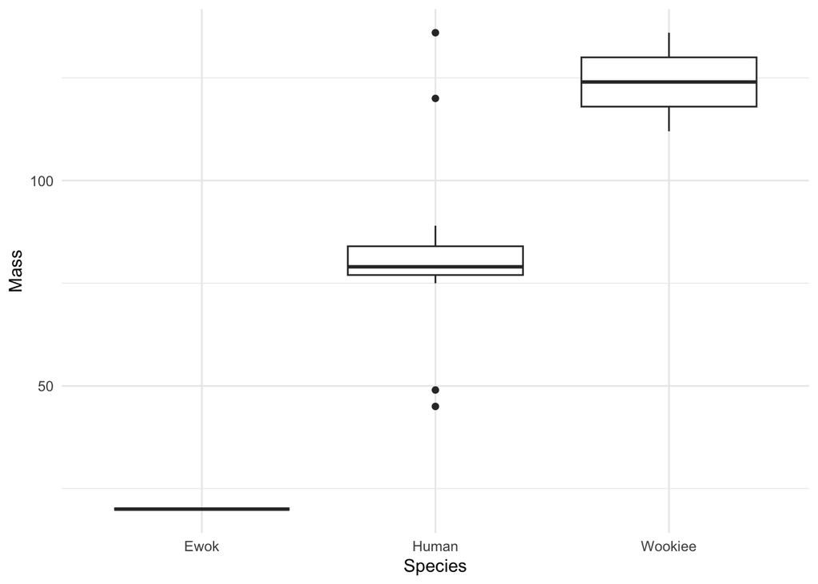

```r
# Include your code below:
ggplot(starwars_subset, aes(x = species, y = mass)) +
  geom_boxplot() +
  theme_minimal() +
  labs(x = "Species",
       y = "Mass")
```

## **Task 16**

Once you complete Tasks 1-15, render an HTML file from this Quarto file. Please consult the lecture 2 slides as needed on how to render an HTML file from your Quarto document.

Remember: assuming all your R code are error free, the HTML file will be generated within the same folder where this Data312Homework3.qmd document resides.

**Please submit both your finalized .qmd and HTML files under Homework 3 in Canvas.**